# ASM - Exercise week 2

Kin Tak Wong, Anne-Kathleen Malchow & Tobias Krüger

April 2, 2021

# 2M1

## (1)

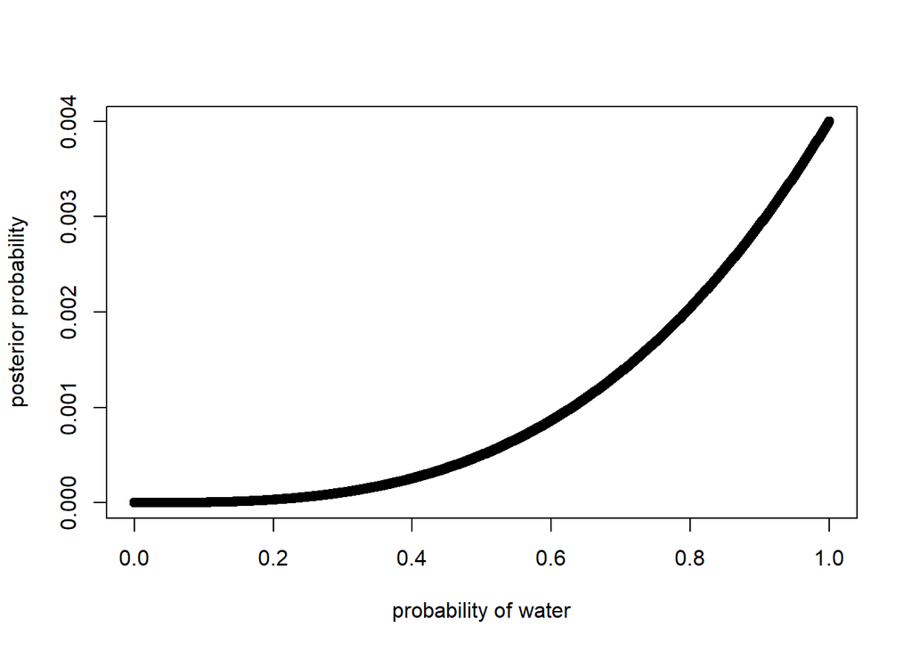

```r
# define grid
res = 1000
p_grid <- seq( from=0 , to=1 , length.out=res )
# define prior
prior <- rep( 1 , res )
# compute likelihood at each value in grid
likelihood <- dbinom( 3 , size=3 , prob=p_grid )
# compute product of likelihood and prior
unstd.posterior <- likelihood * prior
# standardize the posterior, so it sums to 1
posterior <- unstd.posterior / sum(unstd.posterior)
# plot
plot( p_grid , posterior , type="b" ,
      xlab="probability of water" , ylab="posterior probability" )
```

## (2)

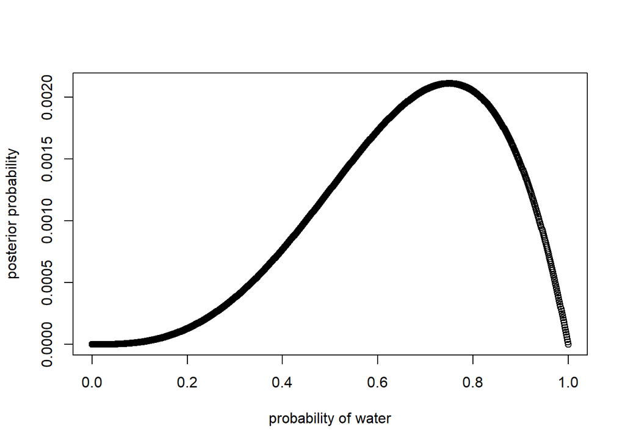

```r
likelihood <- dbinom( 3 , size=4 , prob=p_grid )
unstd.posterior <- likelihood * prior
posterior <- unstd.posterior / sum(unstd.posterior)

plot( p_grid , posterior , type="b" ,
      xlab="probability of water" , ylab="posterior probability" )
```

## (3)

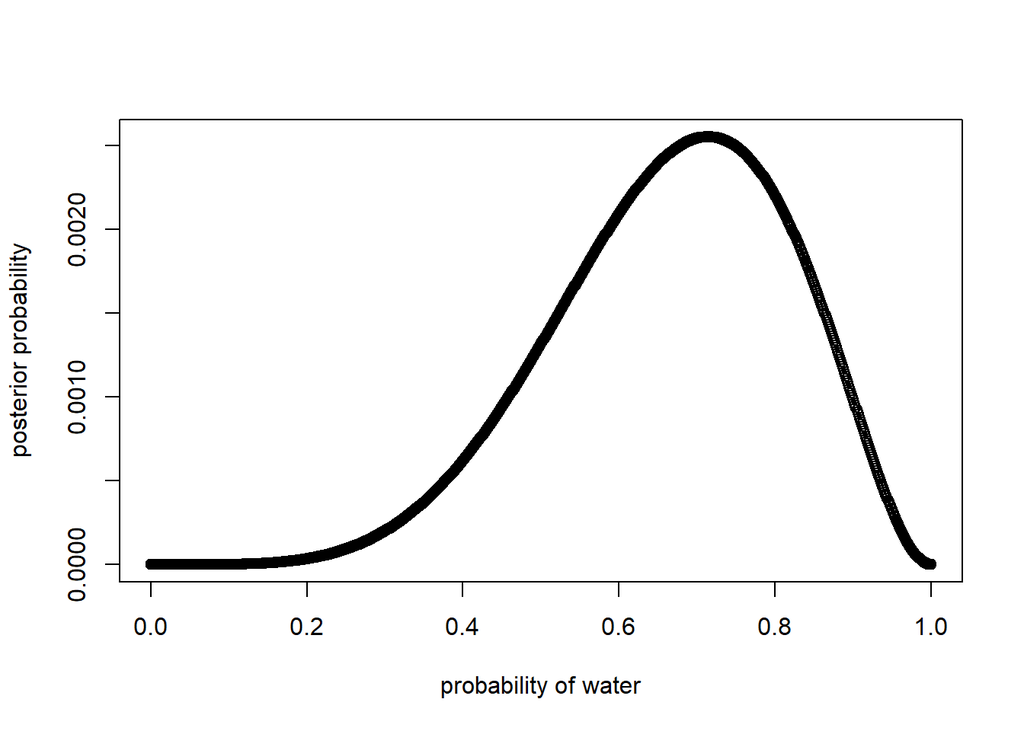

```r
likelihood <- dbinom( 5 , size=7 , prob=p_grid )
unstd.posterior <- likelihood * prior
posterior <- unstd.posterior / sum(unstd.posterior)

plot( p_grid , posterior , type="b" ,
      xlab="probability of water" , ylab="posterior probability" )
```

# 2M2

## new prior

```r
prior <- ifelse( p_grid < 0.5 , 0 , 1 )
```

## (1)

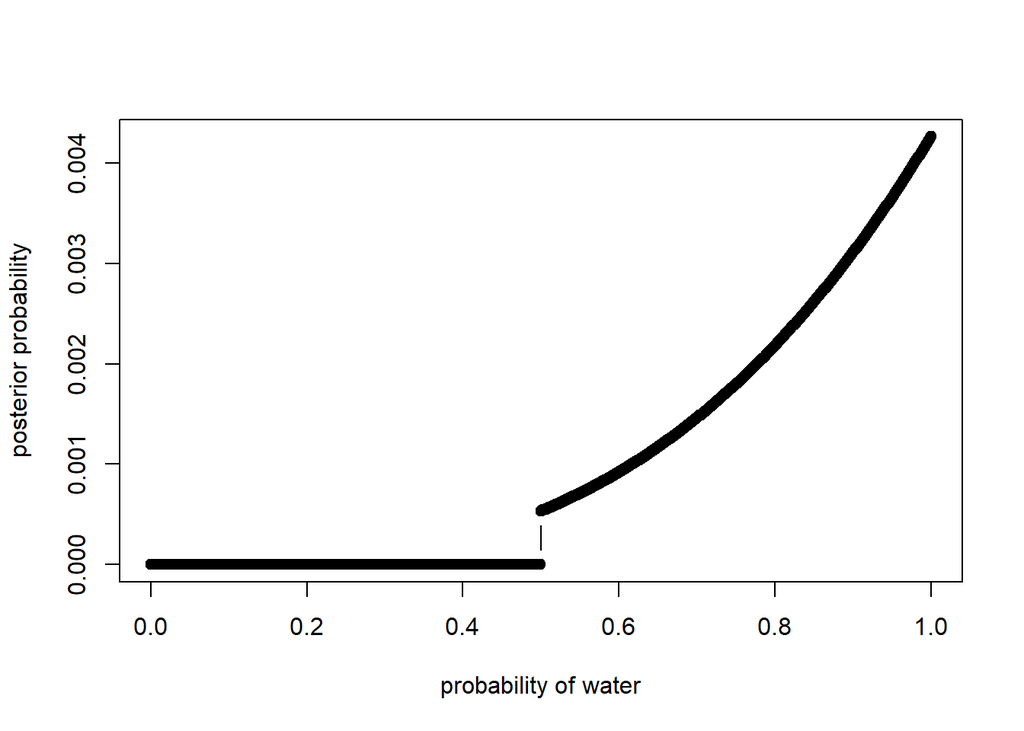

```r
likelihood <- dbinom( 3 , size=3 , prob=p_grid )
unstd.posterior <- likelihood * prior
posterior <- unstd.posterior / sum(unstd.posterior)

plot( p_grid , posterior , type="b" ,
      xlab="probability of water" , ylab="posterior probability" )
```

## (2)

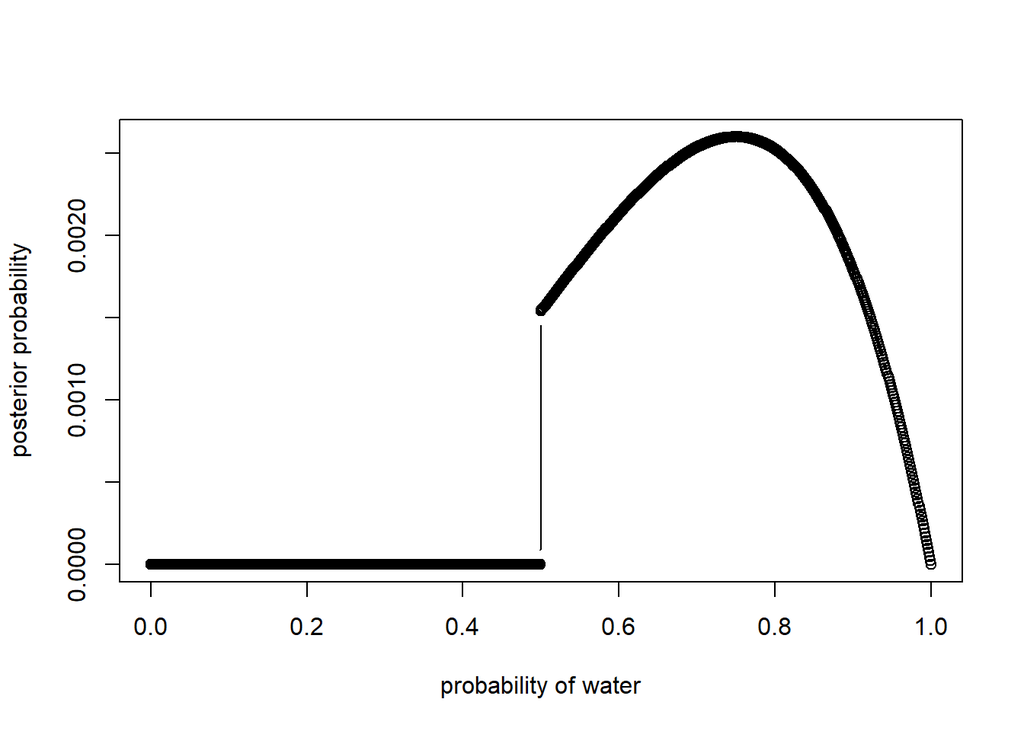

```r
likelihood <- dbinom( 3 , size=4 , prob=p_grid )
unstd.posterior <- likelihood * prior
posterior <- unstd.posterior / sum(unstd.posterior)

plot( p_grid , posterior , type="b" ,
      xlab="probability of water" , ylab="posterior probability" )
```

## (3)

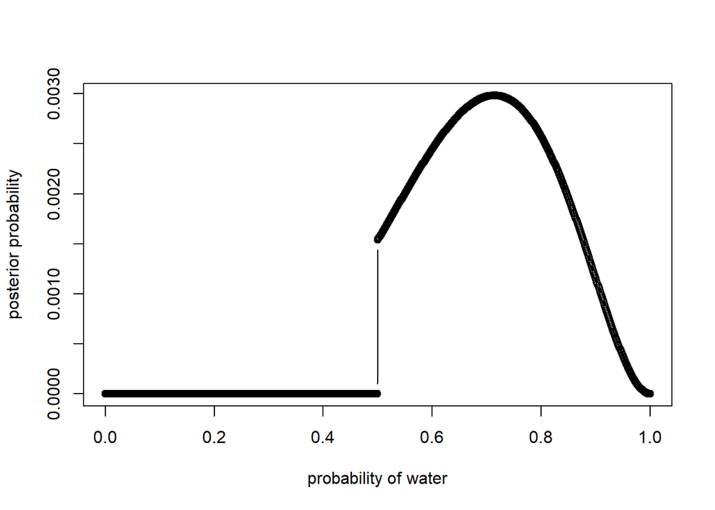

```r
likelihood <- dbinom( 5 , size=7 , prob=p_grid )
unstd.posterior <- likelihood * prior
posterior <- unstd.posterior / sum(unstd.posterior)

plot( p_grid , posterior , type="b" ,
      xlab="probability of water" , ylab="posterior probability" )
```

# 2M3

```r
p_earth <- p_mars <- .5
p_waterIearth <- .7
p_landImars <- 1

p_landIearth <- 1 - p_waterIearth
p_land <- p_landIearth*p_earth + p_landImars*p_mars

(p_earthIland <- p_landIearth*p_earth/p_land)
```

```
## [1] 0.2307692
```

# 2M4

We have three cards and name them B/B, B/W and W/W. The number of ways each card can produce the observed data (black side facing up) is:

- B/B: 2
- B/W: 1
- W/W: 0

Only B/B can produce the second black side, so the probability that the other side is also black is: $\frac{2}{1+2}=\frac{2}{3}$

# 2M5

- B/B: 2
- B/B: 2
- B/W: 1
- W/W: 0

Probability: $\frac{2+2}{1+2+2}=\frac{4}{5}=0.8$

# 2M6

- B/B: 2x1
- B/W: 1x2
- W/W: 0x3

Probability: $\frac{2}{2+2}=\frac{2}{4}=0.5$

# 2M7

If the first card is B/B, then we have 6 ways to produce the observed data:

- B1/B2 & W1/W2
- B1/B2 & W2/W1
- B2/B1 & W1/W2
- B2/B1 & W2/W1
- B1/B2 & B/W
- B2/B1 & B/W

If the first card is B/W, then we have 2 ways to produce the observed data:

- B/W & W1/W2
- B/W & W2/W1

If the first card is W/W, then we have 0 ways to produce the observed data. Therefore, the probability that the first card is B/B based on the observed data is: $\frac{6}{6+2}=\frac{3}{4}=0.75$

# 2H1

Let’s define $\Pr(A)$ as the probability of species $A$ and $\Pr(T)$ as the probability of getting twins. Based on the observed data, we can calculate the posterior probability of species $A$ via Bayes rule:

$$\Pr(A|T)=\frac{\Pr(T|A)\cdot\Pr(A)}{\Pr(T)}$$

We know:

- $\Pr(A)=0.5$
- $\Pr(T|A)=0.1$
- $\Pr(T)=\Pr(T|A)\cdot\Pr(A)+\Pr(T|B)\cdot\Pr(B)=0.1\cdot 0.5+0.2\cdot 0.5=0.15$

Therefore:

$$\Pr(A|T)=\frac{1}{3}:=\Pr'(A)$$
$$\Pr'(B)=1-\Pr'(A)=\frac{2}{3}$$

Based on these updated probabilities of the two species, we can calculate the probability that the next birth is also twins:

$$\Pr'(T)=\Pr(T|A)\cdot \Pr'(A)+\Pr(T|B)\cdot \Pr'(B)=0.1\cdot \frac{1}{3}+0.2\cdot \frac{2}{3}=\frac{1}{6}$$

# 2H2

See 2H1: $\Pr(A|T)=\frac{1}{3}$

# 2H3

We can apply Bayes rule again, using the updated prior from 2H1-2:

$$\Pr(A|S)=\frac{\Pr(S|A)\cdot\Pr'(A)}{\Pr(S)}$$
$$\Pr(A|S)=\frac{0.9\cdot\frac{1}{3}}{0.9\cdot\frac{1}{3}+0.8\cdot\frac{2}{3}}=\frac{9}{25}=0.36:=\Pr''(A)$$

# 2H4

Let’s define $\Pr(+)$ as the probability that the test identifies the species as A. Then Bayes rule, ignoring the birth data, yields:

$$\Pr(A|+)=\frac{\Pr(+|A)\cdot\Pr(A)}{\Pr(+)}$$
$$\Pr(A|+)=\frac{0.8\cdot0.5}{0.8\cdot0.5+0.35\cdot0.5}=0.7$$

Redoing the calculation with the updated prior from 2H3 (after the birth data) yields:

$$\Pr(A|+)=\frac{\Pr(+|A)\cdot\Pr''(A)}{\Pr(+)}$$
$$\Pr(A|+)=\frac{0.8\cdot0.36}{0.8\cdot0.36+0.35\cdot0.64}=0.56$$

Note, another interpretation might be to redo 2H1 (probability of the 2nd birth being also a twin) with the added information from the test.